# Assignment 3

Jake Fell

##Introduction This report is based on a [dataset](https://raw.githubusercontent.com/vera-institute/incarceration-trends/master/incarceration_trends.csv) from the Vera Institute, focusing on incarceration in the United States. This specific study focuses on overall jail population in US Counties, specifically New York County, as well as pretrial data for US Counties and subsequently states. It also looks at the proportion of pretrial populations to the larger jail and total county populations. This information is of note due to the status of persons in pretrial. In some cases these are innocent people and it is important to understand the data of how many of these people are in pretrial and how that compares to persons actually convicted of an offense.

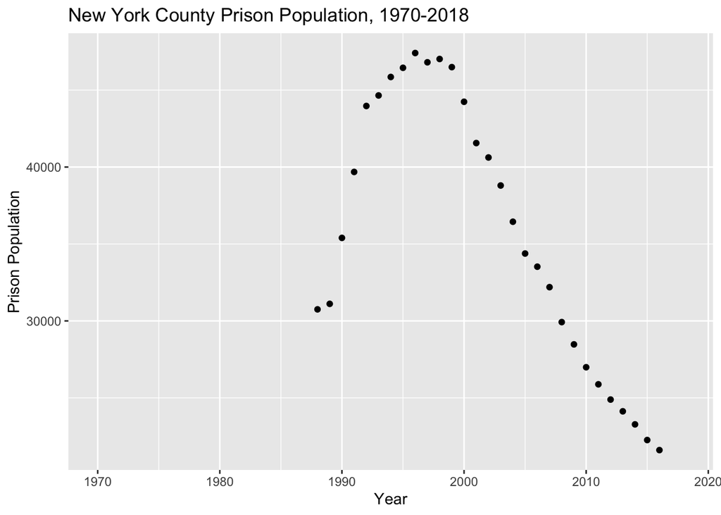

##New York Jail Population vs. Pretrial Population

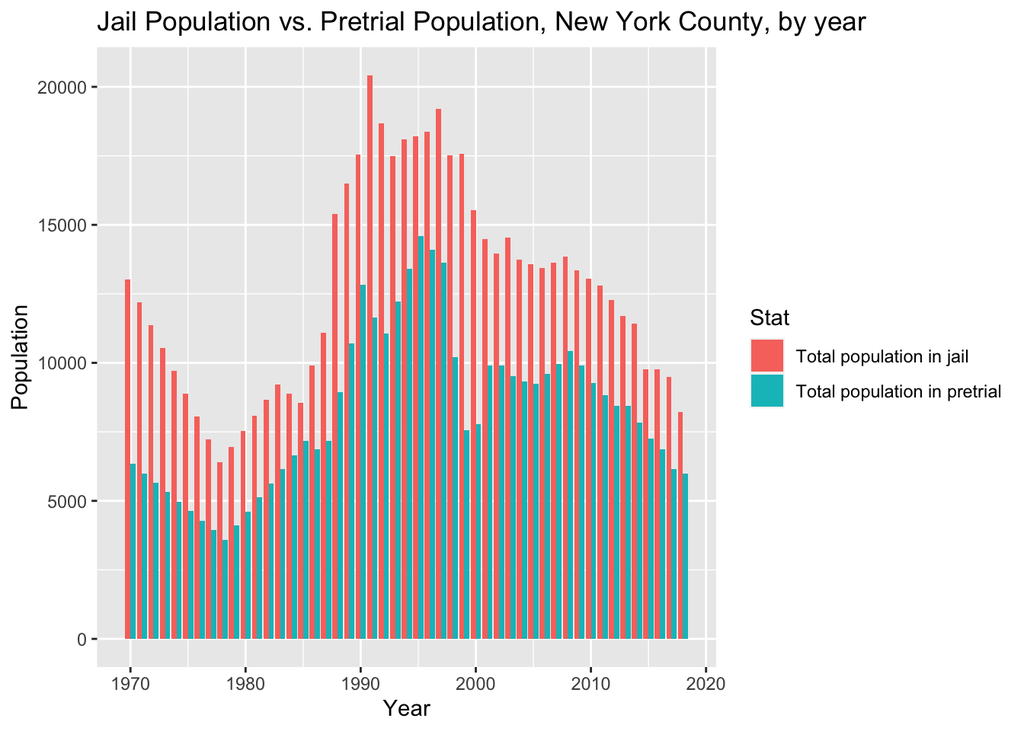

##Total Population of Pretrial Persons in US States in 2018.

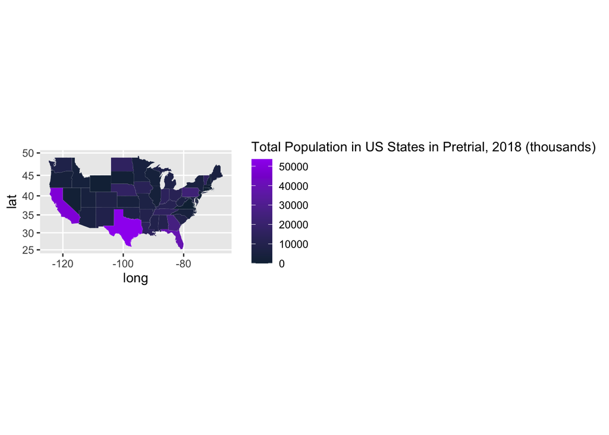